# Week 3 Exercises

# Exercise 1

#### 1.1

Read the *region_scores.csv* data into R. It should have 240 observations of 6 variables.

| region |
| --- |
| South Karelia |
| Satakunta |
| Kymenlaakso |
| Southern Ostrobothnia |
| Uusimaa |
| Kainuu |
| Southern Savonia |
| Pirkanmaa |
| Päijänne Tavastia |
| Central Finland |

[output cut: 7 more lines]

#### 1.2

Cut the continuous variable **age** into a categorical variable **age_group** that has groups of width 10. Use ggplot2’s cutting function.

Count observations by age group.

```r
str(df)
```

[output not shown]

# Exercise 2

The figure should be a scatter plot of **age** on the x-axis and **score** on the y-axis, with points coloured by **education level** (3 levels). It should also have three linear regression lines, one for each of the education levels.

Fix the code to produce the right figure.

What happens if you use `geom_jitter()` instead of `geom_point()`?

**Hint**: Examine the code bit by bit: start by plotting just the scatter plot without `geom_smooth()`, and add the regression lines last.

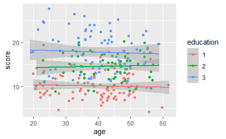

# Exercise 3

#### 3.1

Calculate the mean, standard deviation (sd), and number of observations (n) of **score by education and age group**. Also calculate the standard error of the mean (by using sd and n). Save these into a new data frame (or tibble) named edu_age_stats.

```r
str(edu_age_stats)
```

```
tibble [15 x 6] (S3: tbl_df/tbl/data.frame)
 $ education : Factor w/ 3 levels "1","2","3": 1 1 1 1 1 2 2 2 2 2 ...
 $ age_group : Factor w/ 5 levels "[15,25]","(25,35]",..: 1 2 3 4 5 1 2 3 4 5 ...
 $ mean_score: num [1:15] 10.09 10.2 10.01 10.41 9.03 ...
 $ sd_score  : num [1:15] 2.3 2.81 2.86 2.56 5.51 ...
 $ n         : int [1:15] 12 18 31 20 4 5 15 24 26 7 ...
 $ se_score  : num [1:15] 0.664 0.663 0.515 0.572 2.755 ...
```

#### 3.2

Using edu_age_stats, plot a bar plot that has **age group** on the x-axis, **mean score** on the y-axis, and **education levels** in subplots (facets).

Use `geom_errorbar()` to add error bars that represent standard errors of the mean.

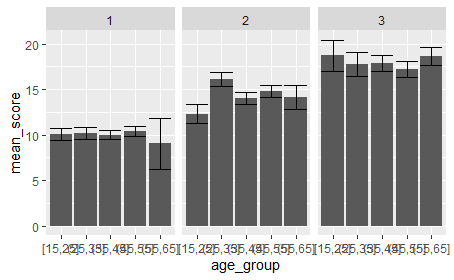

# Exercise 4

#### 4.1

Create a figure that has boxplots of **score** (x-axis) by **region** (y-axis).

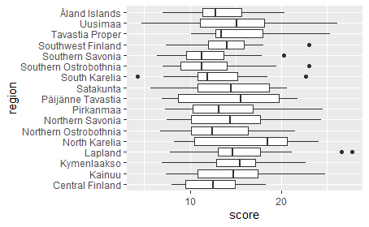

#### 4.2

Group the data by region and add mean score by region to a new column **mean_score**. Do this with **`mutate()`** (not `summarise()`).

Reorder the levels of region based on mean_score.

**Hint**: Remember to ungroup after creating the mean_score variable.

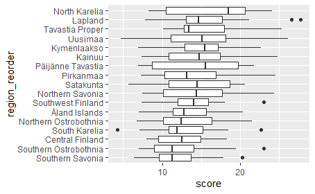

# Exercise 5

Using the data you modified in exercise 4.2, plot **mean scores** (x-axis) by **region** (y-axis) as points. The regions should be ordered by mean score.

**Hint**: Be careful which variable - mean_score or score - you’re plotting in each of the geoms.

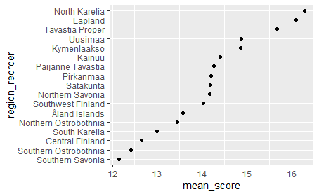